# Graph Visualization

Ali Harb Fall 2018

### Libraries

These are required headers going to be used to download, visualize, and analyze the dataset used in this assignment.

```python
import networkx as nx
import matplotlib.pyplot as plot
from urllib.request import urlopen
import gzip
import matplotlib.colors as mcolors
from multiprocessing import Pool
import itertools
import numpy as np
import community
import collections
%matplotlib inline
```

### Assignment 3

1. Load a graph database of your choosing from a text file or other source. If you take a large network dataset from the web (such as from https://snap.stanford.edu/data/), please feel free at this point to load just a small subset of the nodes and edges.
2. Create basic analysis on the graph, including the graph’s diameter, and at least one other metric of your choosing. You may either code the functions by hand (to build your intuition and insight), or use functions in an existing package.
3. Use a visualization tool of your choice (Neo4j, Gephi, etc.) to display information.
4. Please record a short video (~ 5 minutes), and submit a link to the video as part of your homework submission.

You may work in a small group on this project. Parts one and two should be posted to GitHub and submitted in your assignment link by end of day September 12th. Parts 3 and 4 should be in your video presentation. We may display some of the results in our Meet-up on September 13th

### Import Data

Throughout this assignment, an undirected type social circles dataset of ego-Facebook is being used for visualization analysis from SANP (https://snap.stanford.edu/data/egonets-Facebook.html).This dataset consists of friends from Facebook. The dataset includes node features (profiles), circles, and ego networks.

Download the dataset from SNAP using the Following direct URL (https://snap.stanford.edu/data/facebook_combined.txt.gz) under the name of 'facebook_combined.txt.gz'

```python
  import requests
url = "https://snap.stanford.edu/data/facebook_combined.txt.gz"
r = requests.get(url)
print(type(r))
with open("facebook_combined.txt.gz", "wb") as code:
    code.write(r.content)
```

```
<class 'requests.models.Response'>
```

Print a 100 character of the downloaded file to make sure data is received and takes an insight into the format of the dataset content.

```python
with gzip.open('facebook_combined.txt.gz', 'rb') as f:
    file_content = f.read(100)
    print(file_content)
```

```
b'0 1\n0 2\n0 3\n0 4\n0 5\n0 6\n0 7\n0 8\n0 9\n0 10\n0 11\n0 12\n0 13\n0 14\n0 15\n0 16\n0 17\n0 18\n0 19\n0 20\n0 21\n0 22'
```

### Create Graph

Create a graph from a list of edges from the downloaded Facebook file.

```python
G=nx.read_edgelist('facebook_combined.txt.gz',create_using=nx.Graph(), comments='#',edgetype=int)
```

Print a short summary of the information for the graph such as nodes and edges

```python
print(nx.info(G))
```

```
Name:
Type: Graph
Number of nodes: 4039
Number of edges: 88234
Average degree:  43.6910
```

The summary shows that the number of edges is 20 times the number of nodes. And the average degree of freedom is ~ 44

Use the spring-Embedder to embed the graph nodes and edges

```python
spring_pos=nx.spring_layout(G)
```

### Visualization

Visualize the network by drawing graph

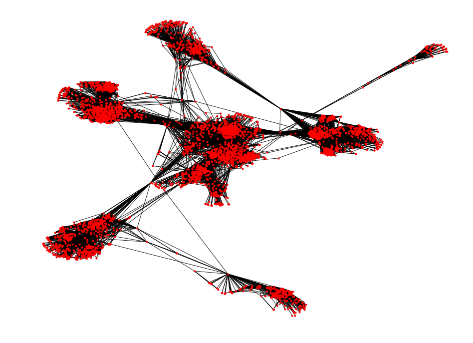

```python
fig = plot.gcf()
fig.set_size_inches(16,12)
plot.axis("off")
nx.draw_networkx(G,pos=spring_pos,with_labels=False,node_size=10,alpha=.9)
```

The plot indicates that the network is composed of very high density clusters of different sizes.

### Analysis

Find the netwrok largest diameter which is the longest shorted path of the network

```python
print(nx.is_connected(G))
components = nx.connected_components(G)
largest_component = max(components, key=len)
subgraph = G.subgraph(largest_component)
diameter = nx.diameter(subgraph)
print("Network diameter of largest component:", diameter)
```

```
True
Network diameter of largest component: 8
```

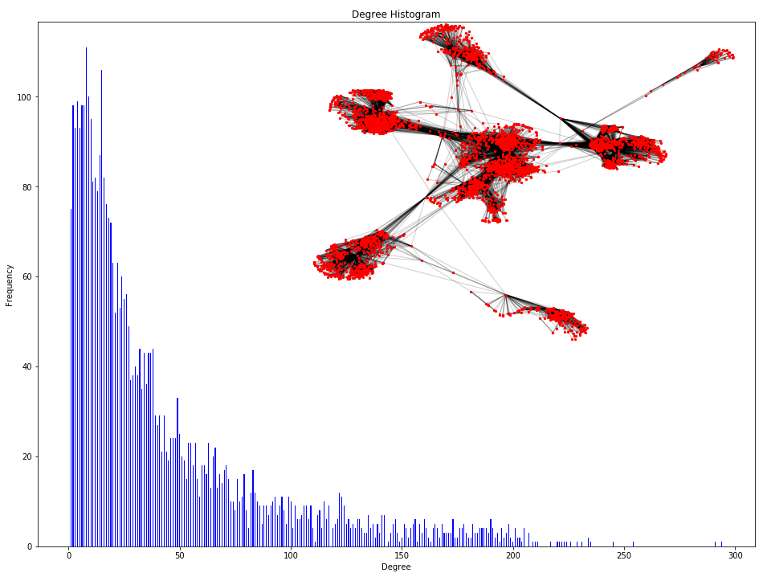

```python
degree_sequence=sorted(dict(nx.degree(G)).values(),reverse=True)
degreeCount =collections.Counter(degree_sequence)
deg, cnt = zip(*degreeCount.items())

# remove some outliers to provide a clean graph
Deg=deg[5:]
Cnt=cnt[5:]


fig, ax = plot.subplots()
plot.bar(Deg, Cnt, width=0.4, color='b')
fig = plot.gcf()
fig.set_size_inches(16,12)
plot.title("Degree Histogram")
plot.ylabel("Frequency")
plot.xlabel("Degree")
#ax.set_xticks([d + 0.4 for d in Deg])
#ax.set_xticklabels(Deg)

# draw graph in inset
plot.axes([0.4, 0.4, 0.5, 0.5])
Gcc = sorted(nx.connected_component_subgraphs(G), key=len, reverse=True)[0]
plot.axis('off')
nx.draw_networkx_nodes(G, spring_pos, node_size=5)
nx.draw_networkx_edges(G, spring_pos, alpha=0.2)

plot.show()
```

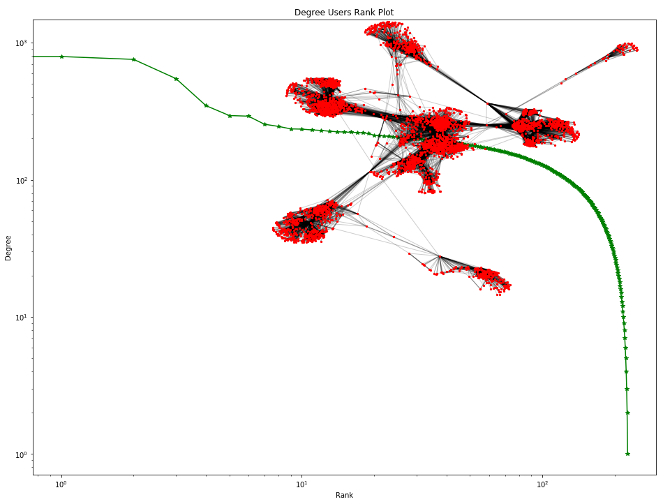

```python
degree_sequence=sorted(dict(nx.degree(G)).values(),reverse=True)
degreeCount =collections.Counter(degree_sequence)
deg, cnt = zip(*degreeCount.items())

fig, ax = plot.subplots()
plot.loglog(deg,"g*-")
fig = plot.gcf()
fig.set_size_inches(16,12)
plot.title("Degree Users Rank Plot")
plot.ylabel("Degree")
plot.xlabel("Rank")
#ax.set_xticks([d + 0.4 for d in Deg])
#ax.set_xticklabels(Deg)

# draw graph in inset
plot.axes([0.4, 0.4, 0.5, 0.5])
Gcc = sorted(nx.connected_component_subgraphs(G), key=len, reverse=True)[0]
plot.axis('off')
nx.draw_networkx_nodes(G, spring_pos, node_size=5)
nx.draw_networkx_edges(G, spring_pos, alpha=0.2)

plot.show()
```

```python
def drawGraph(G, pos, measures, measure_name):

    nodes = nx.draw_networkx_nodes(G, pos, node_size=250, cmap=plot.cm.plasma,
                                   node_color=list(measures.values()),
                                   nodelist=measures.keys())
    nodes.set_norm(mcolors.SymLogNorm(linthresh=0.01, linscale=1))

    # labels = nx.draw_networkx_labels(G, pos)
    edges = nx.draw_networkx_edges(G, pos)



    fig = plot.gcf()
    fig.set_size_inches(16,12)
    plot.title(measure_name)
    plot.colorbar(nodes)
    plot.axis('off')
    plot.show()
```

Find the highest degree of centrality, closeness, and betweenness of the network. At the largest centrality node what is the degree of centrality, closeness, and betweenness? plot the degree centrality of clusters communities

```python
DEGREE_CENTRALITY = nx.degree_centrality(G)
CLOSENESS_CENTRALITY = nx.closeness_centrality(G)
BETWEENNESS_CENTRALITY = nx.betweenness_centrality(G)
```

```python
def largest_node(centrality):
    return list(reversed(sorted((value, node)
                                for (node, value) in centrality.items())))[0][1]

def Centrality_Closness_Betweenness_Centrality(nNode):
    NODE = nNode
    return (DEGREE_CENTRALITY[NODE],
            CLOSENESS_CENTRALITY[NODE], BETWEENNESS_CENTRALITY[NODE])

L=largest_node(nx.degree_centrality(G))
print("The largest degree of centrality node: "+L)
print("The degree of of centrality, closeness, and betweenness at the largets node :")
print("\n\nDEGREE_CENTRALITY | "+ "CLOSENESS_CENTRALITY | "+ "BETWEENNESS_CENTRALITY")
Centrality_Closness_Betweenness_Centrality(L)
```

```
The largest degree of centrality node: 107
The degree of of centrality, closeness, and betweenness at the largets node :


DEGREE_CENTRALITY | CLOSENESS_CENTRALITY | BETWEENNESS_CENTRALITY
```

```
(0.258791480931154, 0.45969945355191255, 0.4805180785560152)
```

Graph the degree centrality of the clustered communities network

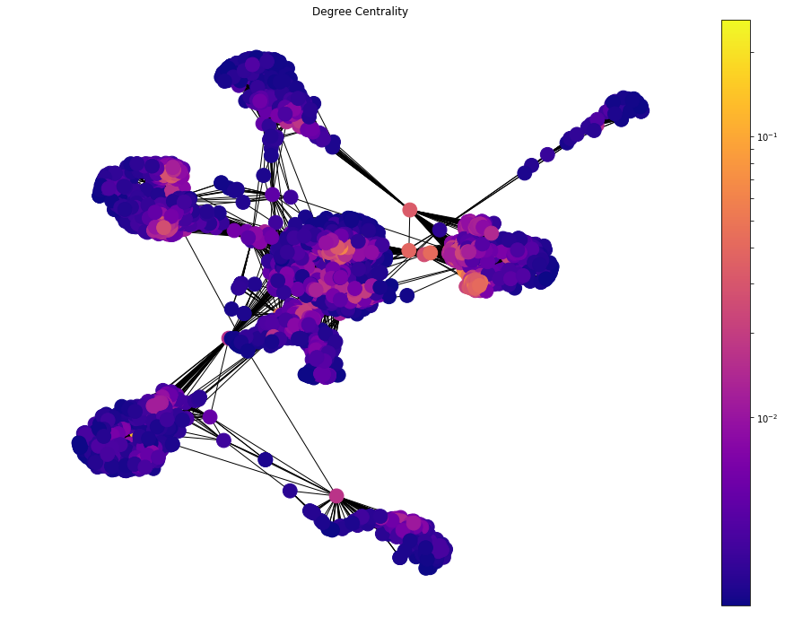

```python
drawGraph(G, spring_pos,nx.degree_centrality(G), 'Degree Centrality')
```

Plot the degree of closeness centrality of the cluster communities network

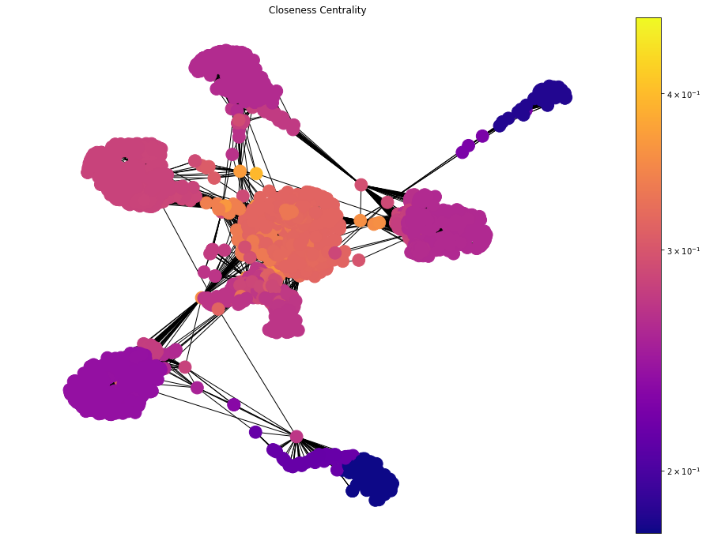

```python
drawGraph(G, spring_pos, nx.closeness_centrality(G), 'Closeness Centrality')
```

Plot the degree of betweenness centrality of the cluster communities network to To identify the key node points of intersections between clusters

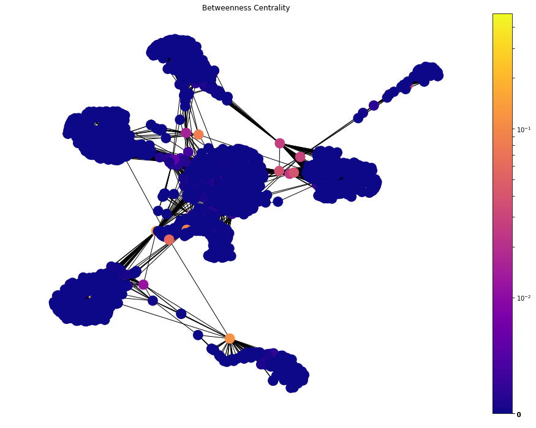

```python
drawGraph(G, spring_pos,  nx.betweenness_centrality(G), 'Betweenness Centrality')
```

Visualize the clustered network with all parts

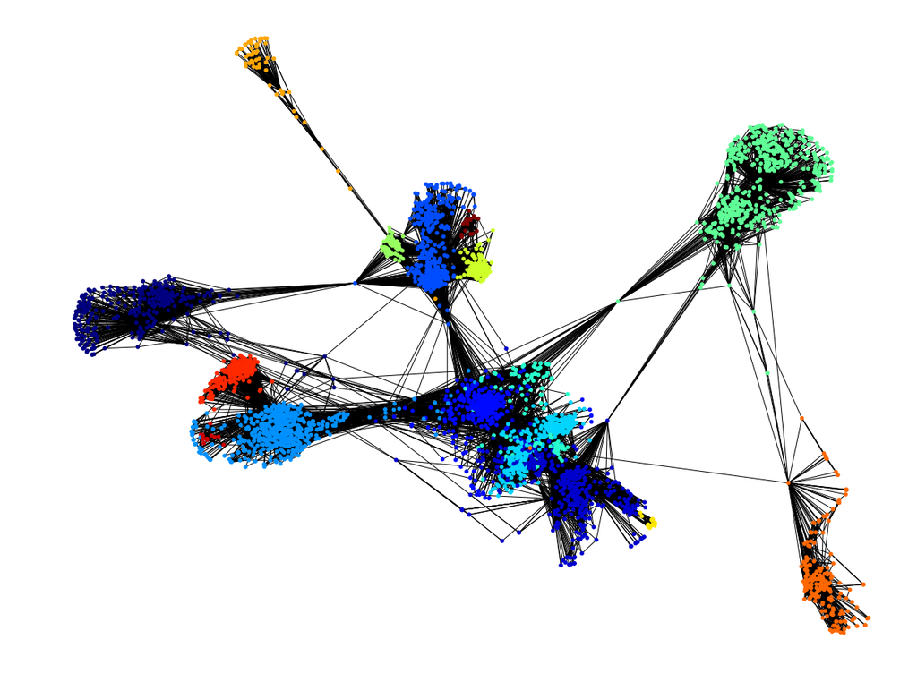

```python
parts = community.best_partition(G)
values = [parts.get(node) for node in G.nodes()]
fig = plot.gcf()
fig.set_size_inches(16,12)
nx.draw_spring(G, cmap = plot.get_cmap('jet'), node_color = values, node_size=20, with_labels=False)
```

Find the modularity of the network

```python
mod = community.modularity(parts,G)
print("modularity:", mod)
```

```
modularity: 0.8349145565369478
```

### Conclusion

The ego- Facebook Is a cluster network with around 16 different communities detected. The highest diameter in the network is 8. The node with largest centricity is 107.

### References

https://blog.dominodatalab.com/social-network-analysis-with-networkx/

https://www.programcreek.com/python/example/89543/networkx.degree_centrality

https://aksakalli.github.io/2017/07/17/network-centrality-measures-and-their-visualization.html

http://ryancompton.net/2014/06/16/community-detection-and-colored-plotting-in-networkx/

https://necromuralist.github.io/data_science/posts/Measures-of-Centrality/